# Aloha Airlines Inc for the year of 2008

## Investigation Overview

In this investigation, I wanted to look at : the range of the delays in minutes Depated time can have a delay, does the flight number has a usualy delay. Does the departed delay effect the arrival? Which are the origins that have the highest delays in minutes? Is there canceled flights? Which are the best places to travel from?

## Dataset Overview

The data after cleaning contains 1418 rows. The columns contains information about the ALoha airlines unique code, day of the week, flight number, tail number, air time, arrival delay in minutes, departed delay in minutes, origin start point of the flight, destination, distance in miles, cancelled code, cancelation which determain if the trip is canceled or not, and date of the trip.

```python
import pandas as pd
import numpy as np
import random
import matplotlib.pyplot as plt
%matplotlib inline
import seaborn as sns
from time import gmtime
from time import strftime
import datetime
from matplotlib.pyplot import figure
```

```python
#read from the new dataframe
df = pd.read_csv('aq.csv')
df.head(4)
```

|  | Unnamed: 0 | DayOfWeek | DepTime | CRSDepTime | ArrTime | CRSArrTime | UniqueCarrier | FlightNum | TailNum | ActualElapsedTime | ... | AirTime | ArrDelay | DepDelay | Origin | Dest | Distance | Cancelled | CancellationCode | Diverted | Date |
| --- | --- | --- | --- | --- | --- | --- | --- | --- | --- | --- | --- | --- | --- | --- | --- | --- | --- | --- | --- | --- | --- |
| 0 | 0 | Tuesday | 15:30:00 | 15:00:00 | 16:10:00 | 15:40:00 | AQ | 26 | N810AL | 38.0 | ... | 29.0 | 33.0 | 32.0 | HNL | OGG | 100 | 0 | NaN | 0 | 2008-1-1 |
| 1 | 1 | Wendesday | 15:10:00 | 15:00:00 | 15:50:00 | 15:40:00 | AQ | 26 | N824AL | 42.0 | ... | 23.0 | 10.0 | 5.0 | HNL | OGG | 100 | 0 | NaN | 0 | 2008-1-2 |
| 2 | 2 | Tursday | 15:00:00 | 15:00:00 | 15:40:00 | 15:40:00 | AQ | 26 | N824AL | 37.0 | ... | 23.0 | -2.0 | -2.0 | HNL | OGG | 100 | 0 | NaN | 0 | 2008-1-3 |
| 3 | 3 | Friday | 15:00:00 | 15:00:00 | 15:40:00 | 15:40:00 | AQ | 26 | N810AL | 41.0 | ... | 23.0 | 5.0 | 1.0 | HNL | OGG | 100 | 0 | NaN | 0 | 2008-1-4 |

4 rows × 21 columns

##### Those figures shows the tail number relation to distance and delays

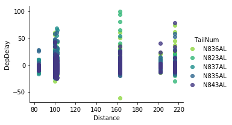

```python
g = sns.FacetGrid(data = df, hue = 'TailNum', hue_order =['N836AL','N823AL','N837AL','N835AL','N843AL'],aspect=1.5,palette='viridis_r')
g.map(sns.regplot,'Distance','DepDelay',x_jitter=0.04,fit_reg=False);
g.add_legend()
```

##### The best flights in this figure are: N843AL N835AL As they have a low delay in minutes weather the flight distance high or low.

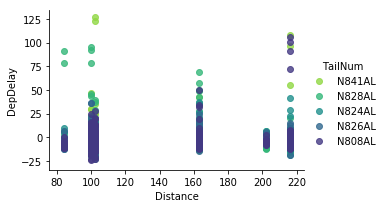

```python
g = sns.FacetGrid(data = df, hue = 'TailNum', hue_order =['N841AL','N828AL','N824AL','N826AL','N808AL'],aspect=1.5,palette='viridis_r')
g.map(sns.regplot,'Distance','DepDelay',x_jitter=0.04,fit_reg=False);
g.add_legend()
```

##### The best flights in this figure are: N826AL As it has a low delay in minutes weather the flight distance high or low.

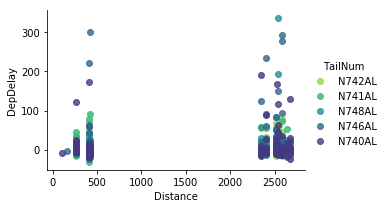

```python
g = sns.FacetGrid(data = df, hue = 'TailNum', hue_order =['N742AL','N741AL','N748AL','N746AL','N740AL'],aspect=1.5,palette='viridis_r')
g.map(sns.regplot,'Distance','DepDelay',x_jitter=0.04,fit_reg=False);
g.add_legend()
```

##### The best flights in this figure are: N741AL N742AL As they have a low delay in minutes weather the flight distance high or low.

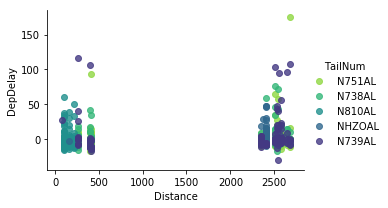

```python
g = sns.FacetGrid(data = df, hue = 'TailNum', hue_order =['N751AL','N738AL','N810AL','NHZOAL','N739AL'],aspect=1.5,palette='viridis_r')
g.map(sns.regplot,'Distance','DepDelay',x_jitter=0.04,fit_reg=False);
g.add_legend()
```

##### The best flights in this figure are: N810AL NHZOAL As they have a low delay in minutes weather the flight distance high or low.

##### Now let's compare all the best airplanes together

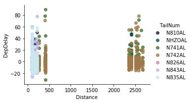

```python
g = sns.FacetGrid(data = df, hue = 'TailNum', hue_order =['N810AL','NHZOAL','N741AL','N742AL','N826AL','N843AL','N835AL'],aspect=1.5,palette='cubehelix')
g.map(sns.regplot,'Distance','DepDelay',x_jitter=0.04,fit_reg=False);
g.add_legend()
```

##### The best flights of all are: N810AL N835AL N843AL N826AL As they have a low delay in minutes weather the flight distance high or low.

```python
df = df[df['DepDelay'] >= 0]
df = df[df['ArrDelay'] >=0]
df.shape[0]
```

```
1418
```

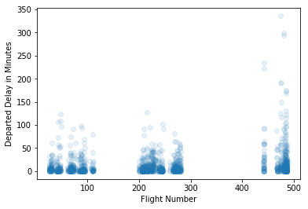

```python
sns.regplot(data = df, x = 'FlightNum', y = 'DepDelay', fit_reg = False,
           x_jitter = 0.2, y_jitter = 0.2, scatter_kws = {'alpha' : 1/10})
plt.xlabel('Flight Number')
plt.ylabel('Departed Delay in Minutes')
```

##### The flights numbers between 450 to 500 are the most delayed flights with max 350 minutes of delay

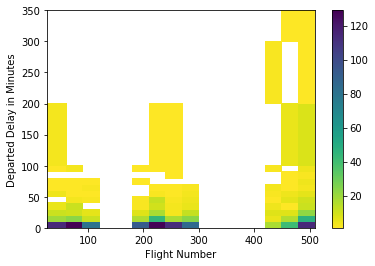

```python
bins_x = [26,60,90,120,150,180,210,240,270,300,330,360,390,420,450,480,510]
bins_y = [0,10,20,30,40,50,60,70,80,90,100,200,300,350]
plt.hist2d(data = df, x = 'FlightNum', y = 'DepDelay',cmin=0.5,cmap = 'viridis_r', bins = [bins_x, bins_y])
plt.colorbar()
plt.xlabel('Flight Number')
plt.ylabel('Departed Delay in Minutes')
```

#### The relation ship between the arrival delay and departed delay are positve as if the plane is departed late by default the arrival will be late

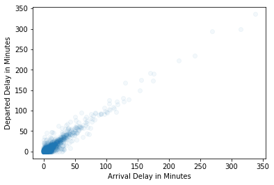

```python
sns.regplot(data = df, x = 'ArrDelay', y = 'DepDelay', fit_reg = False,
           x_jitter = 0.2, y_jitter = 0.2, scatter_kws = {'alpha' : 1/20})
plt.xlabel('Arrival Delay in Minutes')
plt.ylabel('Departed Delay in Minutes')
```

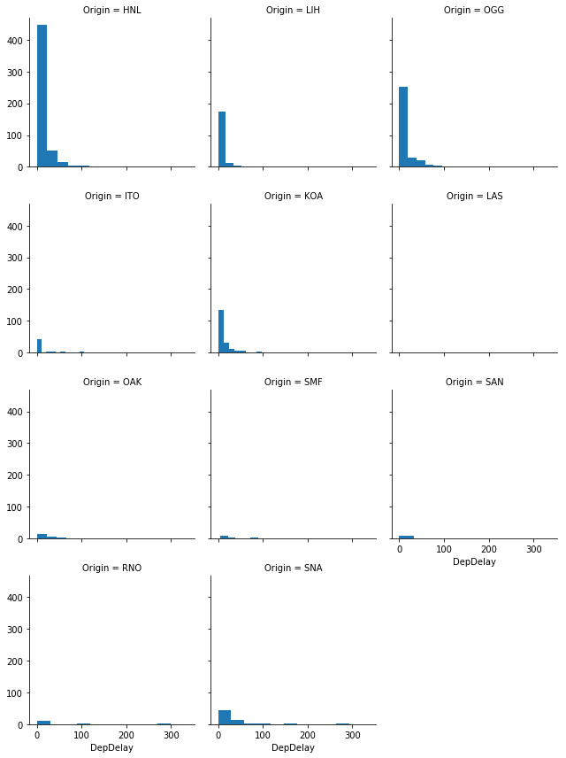

[figure not shown]

```python
g = sns.FacetGrid(data = df, col = 'Origin', col_wrap =3)
g.map(plt.hist, "DepDelay")
figure( figsize=(100, 100))
plt.xlabel('Origin')
plt.xlabel('Departed Delay')
```

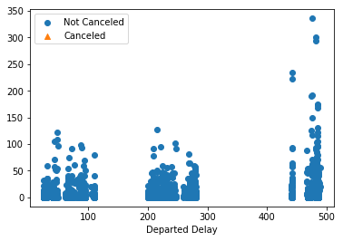

```python
markers = [[0, 'o'],
               [1, '^']]

for m, marker in markers:
    df = df[df['Cancelled'] == m]
    plt.scatter(data = df, x = 'FlightNum', y = 'DepDelay', marker = marker)
plt.legend(['Not Canceled','Canceled'])
plt.xlabel('Flight Number')
plt.xlabel('Departed Delay')
```